# Credit EDA Case Study

### Vijaykumar Rangvani, Shruti Gupta

### 01-12-2021

In this case study, we will be performing risk analysis for the banking and financial services domain.Using exploratory data analysis, we are aiming to identify various factors and patterns that can be helpful in minizing the risk of loosing money while lending to customers.

### Setting up the Libraries

```python
# Filtering out the warnings
import warnings
warnings.filterwarnings("ignore")
```

```python
## Importing the required libraries
import numpy as np
import pandas as pd
import matplotlib.pyplot as plt
import seaborn as sns
%matplotlib inline
```

```python
#Setting Display Options
pd.set_option('display.max_columns', None)
pd.set_option('display.max_rows', None)
```

## Application Data

### Reading & Inspecting the Data

-Reading the Data

```python
#Reading application_data.csv dataset using 'read_csv'
app_df = pd.read_csv("application_data.csv")
```

```python
#Checking Application Data in DataFrame
app_df.head()
```

|  | SK_ID_CURR | TARGET | NAME_CONTRACT_TYPE | CODE_GENDER | FLAG_OWN_CAR | FLAG_OWN_REALTY | CNT_CHILDREN | AMT_INCOME_TOTAL | AMT_CREDIT | AMT_ANNUITY | AMT_GOODS_PRICE | NAME_TYPE_SUITE | NAME_INCOME_TYPE | NAME_EDUCATION_TYPE | NAME_FAMILY_STATUS | NAME_HOUSING_TYPE | REGION_POPULATION_RELATIVE | DAYS_BIRTH | DAYS_EMPLOYED | DAYS_REGISTRATION | DAYS_ID_PUBLISH | OWN_CAR_AGE | FLAG_MOBIL | FLAG_EMP_PHONE | FLAG_WORK_PHONE | FLAG_CONT_MOBILE | FLAG_PHONE | FLAG_EMAIL | OCCUPATION_TYPE | … |
| --- | --- | --- | --- | --- | --- | --- | --- | --- | --- | --- | --- | --- | --- | --- | --- | --- | --- | --- | --- | --- | --- | --- | --- | --- | --- | --- | --- | --- | --- | --- |
| 0 | 100002 | 1 | Cash loans | M | N | Y | 0 | 202500.0 | 406597.5 | 24700.5 | 351000.0 | Unaccompanied | Working | Secondary / secondary special | Single / not married | House / apartment | 0.018801 | -9461 | -637 | -3648.0 | -2120 | NaN | 1 | 1 | 0 | 1 | 1 | 0 | Laborers | … |
| 1 | 100003 | 0 | Cash loans | F | N | N | 0 | 270000.0 | 1293502.5 | 35698.5 | 1129500.0 | Family | State servant | Higher education | Married | House / apartment | 0.003541 | -16765 | -1188 | -1186.0 | -291 | NaN | 1 | 1 | 0 | 1 | 1 | 0 | Core staff | … |
| 2 | 100004 | 0 | Revolving loans | M | Y | Y | 0 | 67500.0 | 135000.0 | 6750.0 | 135000.0 | Unaccompanied | Working | Secondary / secondary special | Single / not married | House / apartment | 0.010032 | -19046 | -225 | -4260.0 | -2531 | 26.0 | 1 | 1 | 1 | 1 | 1 | 0 | Laborers | … |
| 3 | 100006 | 0 | Cash loans | F | N | Y | 0 | 135000.0 | 312682.5 | 29686.5 | 297000.0 | Unaccompanied | Working | Secondary / secondary special | Civil marriage | House / apartment | 0.008019 | -19005 | -3039 | -9833.0 | -2437 | NaN | 1 | 1 | 0 | 1 | 0 | 0 | Laborers | … |
| 4 | 100007 | 0 | Cash loans | M | N | Y | 0 | 121500.0 | 513000.0 | 21865.5 | 513000.0 | Unaccompanied | Working | Secondary / secondary special | Single / not married | House / apartment | 0.028663 | -19932 | -3038 | -4311.0 | -3458 | NaN | 1 | 1 | 0 | 1 | 0 | 0 | Core staff | … |

#### 1.1 Inspecting the Data

```python
#Determining the shape of the datset
print('Shape of the data:',app_df.shape)
```

```
Shape of the data: (307511, 122)
```

```python
#Checking Total No. of Rows-Columns and Total Null Values in DatFrame
print('########## Dataset Infomation ##########')
print ("Rows                 : " ,app_df.shape[0])
print ("Columns              : " ,app_df.shape[1])
print ("Total Missing values : ",app_df.isnull().sum().values.sum())
```

```
########## Dataset Infomation ##########
Rows                 :  307511
Columns              :  122
Total Missing values :  9152465
```

```python
#Verifying column-wise info of the dataframe
app_df.info(verbose=True)
```

```
<class 'pandas.core.frame.DataFrame'>
RangeIndex: 307511 entries, 0 to 307510
Data columns (total 122 columns):
 #    Column                        Dtype
---   ------                        -----
 0    SK_ID_CURR                    int64
 1    TARGET                        int64
 2    NAME_CONTRACT_TYPE            object
 3    CODE_GENDER                   object
 4    FLAG_OWN_CAR                  object
 5    FLAG_OWN_REALTY               object
 6    CNT_CHILDREN                  int64
 7    AMT_INCOME_TOTAL              float64
 8    AMT_CREDIT                    float64
 9    AMT_ANNUITY                   float64
```

[output cut: 114 more lines]

Datatypes seems to be correct for almost all columns

```python
#Checking the summary for the numeric columns
app_df.describe()
```

|  | SK_ID_CURR | TARGET | CNT_CHILDREN | AMT_INCOME_TOTAL | AMT_CREDIT | AMT_ANNUITY | AMT_GOODS_PRICE | REGION_POPULATION_RELATIVE | DAYS_BIRTH | DAYS_EMPLOYED | DAYS_REGISTRATION | DAYS_ID_PUBLISH | OWN_CAR_AGE | FLAG_MOBIL | FLAG_EMP_PHONE | FLAG_WORK_PHONE | FLAG_CONT_MOBILE | FLAG_PHONE | FLAG_EMAIL | CNT_FAM_MEMBERS | REGION_RATING_CLIENT | REGION_RATING_CLIENT_W_CITY | HOUR_APPR_PROCESS_START | REG_REGION_NOT_LIVE_REGION | REG_REGION_NOT_WORK_REGION | LIVE_REGION_NOT_WORK_REGION | REG_CITY_NOT_LIVE_CITY | REG_CITY_NOT_WORK_CITY | LIVE_CITY_NOT_WORK_CITY | … |
| --- | --- | --- | --- | --- | --- | --- | --- | --- | --- | --- | --- | --- | --- | --- | --- | --- | --- | --- | --- | --- | --- | --- | --- | --- | --- | --- | --- | --- | --- | --- |
| count | 307511.000000 | 307511.000000 | 307511.000000 | 3.075110e+05 | 3.075110e+05 | 307499.000000 | 3.072330e+05 | 307511.000000 | 307511.000000 | 307511.000000 | 307511.000000 | 307511.000000 | 104582.000000 | 307511.000000 | 307511.000000 | 307511.000000 | 307511.000000 | 307511.000000 | 307511.000000 | 307509.000000 | 307511.000000 | 307511.000000 | 307511.000000 | 307511.000000 | 307511.000000 | 307511.000000 | 307511.000000 | 307511.000000 | 307511.000000 | … |
| mean | 278180.518577 | 0.080729 | 0.417052 | 1.687979e+05 | 5.990260e+05 | 27108.573909 | 5.383962e+05 | 0.020868 | -16036.995067 | 63815.045904 | -4986.120328 | -2994.202373 | 12.061091 | 0.999997 | 0.819889 | 0.199368 | 0.998133 | 0.281066 | 0.056720 | 2.152665 | 2.052463 | 2.031521 | 12.063419 | 0.015144 | 0.050769 | 0.040659 | 0.078173 | 0.230454 | 0.179555 | … |
| std | 102790.175348 | 0.272419 | 0.722121 | 2.371231e+05 | 4.024908e+05 | 14493.737315 | 3.694465e+05 | 0.013831 | 4363.988632 | 141275.766519 | 3522.886321 | 1509.450419 | 11.944812 | 0.001803 | 0.384280 | 0.399526 | 0.043164 | 0.449521 | 0.231307 | 0.910682 | 0.509034 | 0.502737 | 3.265832 | 0.122126 | 0.219526 | 0.197499 | 0.268444 | 0.421124 | 0.383817 | … |
| min | 100002.000000 | 0.000000 | 0.000000 | 2.565000e+04 | 4.500000e+04 | 1615.500000 | 4.050000e+04 | 0.000290 | -25229.000000 | -17912.000000 | -24672.000000 | -7197.000000 | 0.000000 | 0.000000 | 0.000000 | 0.000000 | 0.000000 | 0.000000 | 0.000000 | 1.000000 | 1.000000 | 1.000000 | 0.000000 | 0.000000 | 0.000000 | 0.000000 | 0.000000 | 0.000000 | 0.000000 | … |
| 25% | 189145.500000 | 0.000000 | 0.000000 | 1.125000e+05 | 2.700000e+05 | 16524.000000 | 2.385000e+05 | 0.010006 | -19682.000000 | -2760.000000 | -7479.500000 | -4299.000000 | 5.000000 | 1.000000 | 1.000000 | 0.000000 | 1.000000 | 0.000000 | 0.000000 | 2.000000 | 2.000000 | 2.000000 | 10.000000 | 0.000000 | 0.000000 | 0.000000 | 0.000000 | 0.000000 | 0.000000 | … |
| 50% | 278202.000000 | 0.000000 | 0.000000 | 1.471500e+05 | 5.135310e+05 | 24903.000000 | 4.500000e+05 | 0.018850 | -15750.000000 | -1213.000000 | -4504.000000 | -3254.000000 | 9.000000 | 1.000000 | 1.000000 | 0.000000 | 1.000000 | 0.000000 | 0.000000 | 2.000000 | 2.000000 | 2.000000 | 12.000000 | 0.000000 | 0.000000 | 0.000000 | 0.000000 | 0.000000 | 0.000000 | … |
| 75% | 367142.500000 | 0.000000 | 1.000000 | 2.025000e+05 | 8.086500e+05 | 34596.000000 | 6.795000e+05 | 0.028663 | -12413.000000 | -289.000000 | -2010.000000 | -1720.000000 | 15.000000 | 1.000000 | 1.000000 | 0.000000 | 1.000000 | 1.000000 | 0.000000 | 3.000000 | 2.000000 | 2.000000 | 14.000000 | 0.000000 | 0.000000 | 0.000000 | 0.000000 | 0.000000 | 0.000000 | … |
| max | 456255.000000 | 1.000000 | 19.000000 | 1.170000e+08 | 4.050000e+06 | 258025.500000 | 4.050000e+06 | 0.072508 | -7489.000000 | 365243.000000 | 0.000000 | 0.000000 | 91.000000 | 1.000000 | 1.000000 | 1.000000 | 1.000000 | 1.000000 | 1.000000 | 20.000000 | 3.000000 | 3.000000 | 23.000000 | 1.000000 | 1.000000 | 1.000000 | 1.000000 | 1.000000 | 1.000000 | … |

```python
#Checking the summary for the Categorical columns
app_df[list(set(app_df.columns) - set(app_df.describe().columns))].agg({'count','nunique'})
```

|  | NAME_TYPE_SUITE | ORGANIZATION_TYPE | FONDKAPREMONT_MODE | NAME_INCOME_TYPE | FLAG_OWN_CAR | EMERGENCYSTATE_MODE | NAME_CONTRACT_TYPE | OCCUPATION_TYPE | NAME_EDUCATION_TYPE | CODE_GENDER | WALLSMATERIAL_MODE | NAME_HOUSING_TYPE | WEEKDAY_APPR_PROCESS_START | FLAG_OWN_REALTY | NAME_FAMILY_STATUS | HOUSETYPE_MODE |
| --- | --- | --- | --- | --- | --- | --- | --- | --- | --- | --- | --- | --- | --- | --- | --- | --- |
| count | 306219 | 307511 | 97216 | 307511 | 307511 | 161756 | 307511 | 211120 | 307511 | 307511 | 151170 | 307511 | 307511 | 307511 | 307511 | 153214 |
| nunique | 7 | 58 | 4 | 8 | 2 | 2 | 2 | 18 | 5 | 3 | 7 | 6 | 7 | 2 | 6 | 3 |

## PART A: DATA CLEANING

### 1. Fixing Columns

```python
#checking missing values in each column and sorting columns in Descending order
app_df.isnull().sum().sort_values(ascending=False)
```

```
COMMONAREA_MEDI                 214865
COMMONAREA_AVG                  214865
COMMONAREA_MODE                 214865
NONLIVINGAPARTMENTS_MODE        213514
NONLIVINGAPARTMENTS_AVG         213514
NONLIVINGAPARTMENTS_MEDI        213514
FONDKAPREMONT_MODE              210295
LIVINGAPARTMENTS_MODE           210199
LIVINGAPARTMENTS_AVG            210199
LIVINGAPARTMENTS_MEDI           210199
FLOORSMIN_AVG                   208642
FLOORSMIN_MODE                  208642
FLOORSMIN_MEDI                  208642
YEARS_BUILD_MEDI                204488
YEARS_BUILD_MODE                204488
YEARS_BUILD_AVG                 204488
OWN_CAR_AGE                     202929
LANDAREA_MEDI                   182590
LANDAREA_MODE                   182590
LANDAREA_AVG                    182590
BASEMENTAREA_MEDI               179943
BASEMENTAREA_AVG                179943
BASEMENTAREA_MODE               179943
EXT_SOURCE_1                    173378
NONLIVINGAREA_MODE              169682
NONLIVINGAREA_AVG               169682
NONLIVINGAREA_MEDI              169682
ELEVATORS_MEDI                  163891
ELEVATORS_AVG                   163891
ELEVATORS_MODE                  163891
WALLSMATERIAL_MODE              156341
APARTMENTS_MEDI                 156061
APARTMENTS_AVG                  156061
APARTMENTS_MODE                 156061
ENTRANCES_MEDI                  154828
ENTRANCES_AVG                   154828
ENTRANCES_MODE                  154828
LIVINGAREA_AVG                  154350
LIVINGAREA_MODE                 154350
LIVINGAREA_MEDI                 154350
```

[output cut: 68 more lines]

```
ORGANIZATION_TYPE                    0
FLAG_WORK_PHONE                      0
FLAG_EMP_PHONE                       0
FLAG_MOBIL                           0
DAYS_ID_PUBLISH                      0
DAYS_REGISTRATION                    0
DAYS_EMPLOYED                        0
DAYS_BIRTH                           0
REGION_POPULATION_RELATIVE           0
NAME_HOUSING_TYPE                    0
NAME_FAMILY_STATUS                   0
NAME_EDUCATION_TYPE                  0
NAME_INCOME_TYPE                     0
SK_ID_CURR                           0
dtype: int64
```

```python
# calculating column-wise percentage of missing values and storing it in app_null_df
app_null_df = round(100*(app_df.isnull().sum() / len(app_df.index)), 2)
app_null_df.head()
```

```
SK_ID_CURR            0.0
TARGET                0.0
NAME_CONTRACT_TYPE    0.0
CODE_GENDER           0.0
FLAG_OWN_CAR          0.0
dtype: float64
```

```python
#Counting No. of Columns having more than 45% null value
print("Columns having 45% null value: ", app_null_df[app_null_df>45].size)
```

```
Columns having 45% null value:  49
```

- It was observerd that there are 49 columns that are having more than 45% values as null values .
- We will be dropping these null values from our orignal dataframe app_df.

```python
#Dropping columns having null values more than 45% from app_df dataframe
app_df.drop(columns = app_null_df[app_null_df>45].index, axis = 1,inplace=True)
print('Size of the dataset after removing the missing values',app_df.shape)
```

```
Size of the dataset after removing the missing values (307511, 73)
```

```python
#checking missing values in each column and sorting columns in Descending order
round(100 *(app_df.isnull().sum()/len(app_df.index)),2).sort_values(ascending=False).head()
```

```
OCCUPATION_TYPE               31.35
EXT_SOURCE_3                  19.83
AMT_REQ_CREDIT_BUREAU_YEAR    13.50
AMT_REQ_CREDIT_BUREAU_QRT     13.50
AMT_REQ_CREDIT_BUREAU_MON     13.50
dtype: float64
```

- It was observed that there are most of the columns stating with keyword 'Flag' are not useful for analysis.Hence, we will be dropping those columns
- Coulmns: FLAG_OWN_CAR(Flag if the client owns a car) & FLAG_OWN_REALTY(Flag if client owns a house or flat) are exceptions to the above condition as they determine the useful data for anaylsis of client financial status.Hence we won't drop these two columns
- It was observed that there are most of the columns stating with keyword 'SOCIAL_CIRCLE' are not useful for analysis.Hence, we will be dropping those columns
- Also, column EXT_SOURCE_3,CNT_FAM_MEMBERS,DAYS_LAST_PHONE_CHANGE and NAME_TYPE_SUITE are not contaning any relevant data that can be useful for anaylsis hence will be dropping that too.
- Total unwanted columns identified from above anaylsis are 34.This will be removed from application_data dataframe.

```python
#Identiying the columns that are not useful for our case study anylsis and dropping them manually
drop_col = ['EXT_SOURCE_3','NAME_TYPE_SUITE','OBS_30_CNT_SOCIAL_CIRCLE','DEF_30_CNT_SOCIAL_CIRCLE','OBS_60_CNT_SOCIAL_CIRCLE',
           'DEF_60_CNT_SOCIAL_CIRCLE','FLAG_DOCUMENT_8','FLAG_DOCUMENT_2','FLAG_DOCUMENT_3','FLAG_DOCUMENT_4','FLAG_DOCUMENT_5',
           'FLAG_DOCUMENT_6','FLAG_DOCUMENT_7','FLAG_DOCUMENT_12','FLAG_DOCUMENT_9','FLAG_DOCUMENT_10','FLAG_DOCUMENT_11',
           'FLAG_DOCUMENT_13','FLAG_DOCUMENT_14','FLAG_DOCUMENT_15','FLAG_DOCUMENT_16','FLAG_DOCUMENT_17','FLAG_DOCUMENT_18',
           'FLAG_DOCUMENT_19','FLAG_DOCUMENT_20','FLAG_DOCUMENT_21','FLAG_MOBIL','FLAG_EMP_PHONE','FLAG_WORK_PHONE','FLAG_CONT_MOBILE','FLAG_PHONE','FLAG_EMAIL','CNT_FAM_MEMBERS', 'DAYS_LAST_PHONE_CHANGE']

#Displaying No. of columns that needs to be dropped
len(drop_col)
```

```
34
```

```python
#Dropping Unwanted olumns from data
app_df.drop(columns=drop_col,axis=1,inplace=True)
print('Size of the dataset after removing the missing values',app_df.shape)
```

```
Size of the dataset after removing the missing values (307511, 39)
```

### 2 Handling the Missing value

```python
#Getting list of columns with null values
app_df.columns[app_df.isnull().any()].tolist()
```

```
['AMT_ANNUITY',
 'AMT_GOODS_PRICE',
 'OCCUPATION_TYPE',
 'EXT_SOURCE_2',
 'AMT_REQ_CREDIT_BUREAU_HOUR',
 'AMT_REQ_CREDIT_BUREAU_DAY',
 'AMT_REQ_CREDIT_BUREAU_WEEK',
 'AMT_REQ_CREDIT_BUREAU_MON',
 'AMT_REQ_CREDIT_BUREAU_QRT',
 'AMT_REQ_CREDIT_BUREAU_YEAR']
```

```python
#Checking the no. of null values column-wise
app_df.isnull().sum().sort_values(ascending=False).head(10)
```

```
OCCUPATION_TYPE               96391
AMT_REQ_CREDIT_BUREAU_WEEK    41519
AMT_REQ_CREDIT_BUREAU_HOUR    41519
AMT_REQ_CREDIT_BUREAU_DAY     41519
AMT_REQ_CREDIT_BUREAU_YEAR    41519
AMT_REQ_CREDIT_BUREAU_MON     41519
AMT_REQ_CREDIT_BUREAU_QRT     41519
EXT_SOURCE_2                    660
AMT_GOODS_PRICE                 278
AMT_ANNUITY                      12
dtype: int64
```

```python
#Dealing squentially with each column having Null Value
#Checking for 'OCCUPATION_TYPE' Column Null Values
app_df['OCCUPATION_TYPE'].value_counts()
```

```
Laborers                 55186
Sales staff              32102
Core staff               27570
Managers                 21371
Drivers                  18603
High skill tech staff    11380
Accountants               9813
Medicine staff            8537
Security staff            6721
Cooking staff             5946
Cleaning staff            4653
Private service staff     2652
Low-skill Laborers        2093
Waiters/barmen staff      1348
Secretaries               1305
Realty agents              751
HR staff                   563
IT staff                   526
Name: OCCUPATION_TYPE, dtype: int64
```

```python
#Imputing Null value for  Occupation Type column using mode
app_df['OCCUPATION_TYPE'].fillna(app_df['OCCUPATION_TYPE'].mode()[0],inplace=True)
```

```python
#Checking for 'AMT_ANNUITY' Column Null Values
app_df['AMT_ANNUITY'].describe()
```

```
count    307499.000000
mean      27108.573909
std       14493.737315
min        1615.500000
25%       16524.000000
50%       24903.000000
75%       34596.000000
max      258025.500000
Name: AMT_ANNUITY, dtype: float64
```

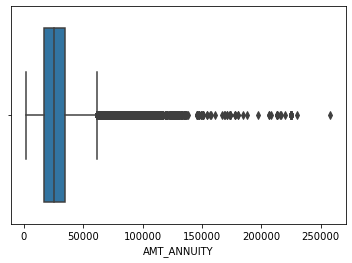

```python
#plotting box-plot for 'AMT_ANNUITY' column inorder to verify the presence of outliers
sns.boxplot(app_df["AMT_ANNUITY"])
plt.show()
```

As,'AMT_ANNUITY' column is having an outlier.hence we will be using Median to impute null value.

```python
#Imputing Null value of AMT_ANNUITY column using median
app_df['AMT_ANNUITY'].fillna(app_df['AMT_ANNUITY'].median(),inplace=True)
```

```python
#Checking for 'EXT_SOURCE_2' Column Null Values
app_df['EXT_SOURCE_2'].describe()
```

```
count    3.068510e+05
mean     5.143927e-01
std      1.910602e-01
min      8.173617e-08
25%      3.924574e-01
50%      5.659614e-01
75%      6.636171e-01
max      8.549997e-01
Name: EXT_SOURCE_2, dtype: float64
```

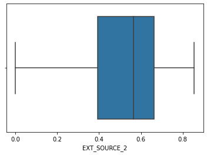

```python
#plotting box-plot for 'EXT_SOURCE_2' column inorder to verify the presence of outliers
sns.boxplot(app_df["EXT_SOURCE_2"])
plt.show()
```

```python
#Imputing Missing value for EXT_SOURCE_2 column using mode
app_df['EXT_SOURCE_2'].fillna(app_df['EXT_SOURCE_2'].mode()[0],inplace=True)
```

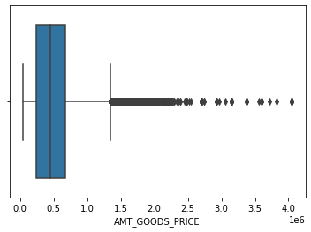

```python
#plotting box-plot for 'AMT_GOODS_PRICE' column inorder to verify the presence of outliers
sns.boxplot(app_df["AMT_GOODS_PRICE"])
plt.show()
```

```python
#Filling Null value for AMT_GOODS_PRICE column using median & changing AMT_GOODS_PRICE Data type to int from float
app_df['AMT_GOODS_PRICE']=app_df['AMT_GOODS_PRICE'].fillna(0.0).astype(int)
```

- Columns starting with 'AMT_REQ' are basically no. of enquiries to Credit Bureau for applying any other loan parallely.
- Hence this can be imputed with Mode value of the respected column.

```python
#Checking for Null Values of Columns starting with 'AMT_REQ'

for col in app_df.columns:
    if col.startswith("AMT_REQ"):
        print(app_df[col].value_counts())
        print("\n")
```

```
0.0    264366
1.0      1560
2.0        56
3.0         9
4.0         1
Name: AMT_REQ_CREDIT_BUREAU_HOUR, dtype: int64


0.0    264503
1.0      1292
2.0       106
3.0        45
4.0        26
5.0         9
6.0         8
9.0         2
8.0         1
Name: AMT_REQ_CREDIT_BUREAU_DAY, dtype: int64


0.0    257456
1.0      8208
2.0       199
3.0        58
4.0        34
6.0        20
5.0        10
8.0         5
7.0         2
Name: AMT_REQ_CREDIT_BUREAU_WEEK, dtype: int64


0.0     222233
1.0      33147
2.0       5386
3.0       1991
4.0       1076
5.0        602
6.0        343
7.0        298
```

[output cut: 44 more lines]

```
12.0       30
10.0       22
13.0       19
14.0       10
17.0        7
15.0        6
18.0        4
19.0        4
16.0        3
25.0        1
21.0        1
22.0        1
20.0        1
23.0        1
Name: AMT_REQ_CREDIT_BUREAU_YEAR, dtype: int64
```

```python
#Imputing Missing value of Columns starting with 'AMT_REQ' using mode

for i in app_df.columns:
    if i.startswith("AMT_REQ"):
        app_df[i].fillna(value=(app_df[i].mode()[0]), inplace=True)
```

```python
#After imputing of null values verifying total no. of null values
print ("Total Missing values : ",app_df.isnull().sum().values.sum())
```

```
Total Missing values :  0
```

### 3 Standardising & Fixing Invalid Values

```python
# It seems like columns starting with 'DAYS'  are having negative values.
#Using unique function to verify

for i in app_df.columns:
        if i.startswith("DAYS"):
            print(app_df[i].unique())
```

```
[ -9461 -16765 -19046 ...  -7951  -7857 -25061]
[  -637  -1188   -225 ... -12971 -11084  -8694]
[ -3648.  -1186.  -4260. ... -16396. -14558. -14798.]
[-2120  -291 -2531 ... -6194 -5854 -6211]
```

```python
#Converting negative values to postive values using abs function
for i in app_df.columns:
    if i.startswith("DAYS"):
        app_df[i]= abs(app_df[i])
```

```python
#Re-verifying the columns starting with 'DAYS'
for i in app_df.columns:
        if i.startswith("DAYS"):
            print(app_df[i].unique())
```

```
[ 9461 16765 19046 ...  7951  7857 25061]
[  637  1188   225 ... 12971 11084  8694]
[ 3648.  1186.  4260. ... 16396. 14558. 14798.]
[2120  291 2531 ... 6194 5854 6211]
```

```python
#converting DAYS_BIRTH column to year and converting the data type to integer
app_df['DAYS_BIRTH'] = (app_df['DAYS_BIRTH'] // 365).astype(int)
```

```python
#Dealing squentially with each column having XNA value
#Verifying the value_counts for "CODE_GENDER"column
app_df['CODE_GENDER'].value_counts()
```

```
F      202448
M      105059
XNA         4
Name: CODE_GENDER, dtype: int64
```

```python
#Imputing XNA value with F
app_df.loc[app_df['CODE_GENDER'] == 'XNA','CODE_GENDER'] = 'F'
app_df.CODE_GENDER.value_counts()
```

```
F    202452
M    105059
Name: CODE_GENDER, dtype: int64
```

```python
# Verifying the value_counts for "ORGANIZATION_TYPE"column
app_df['ORGANIZATION_TYPE'].value_counts().head()
```

```
Business Entity Type 3    67992
XNA                       55374
Self-employed             38412
Other                     16683
Medicine                  11193
Name: ORGANIZATION_TYPE, dtype: int64
```

- Column `XNA` has `55374` values,which is a huge number in comparison to the total customers.
- Hence, it cannot be filled with any category.
- It can be replaced by `NaN`.

```python
# Imputing XNA value with NaN
app_df.replace('XNA',np.NaN,inplace=True)
app_df.ORGANIZATION_TYPE.value_counts(dropna = False).head()
```

```
Business Entity Type 3    67992
NaN                       55374
Self-employed             38412
Other                     16683
Medicine                  11193
Name: ORGANIZATION_TYPE, dtype: int64
```

### 4.Handling Outliers

```python
#Verifying the summary and different percentile values  for selected columns with aim to check of outlier detection
round(app_df[['AMT_INCOME_TOTAL','AMT_CREDIT','AMT_ANNUITY','AMT_GOODS_PRICE']].describe(percentiles = [0.25, 0.50, 0.75, 0.95, .99]))
```

|  | AMT_INCOME_TOTAL | AMT_CREDIT | AMT_ANNUITY | AMT_GOODS_PRICE |
| --- | --- | --- | --- | --- |
| count | 307511.0 | 307511.0 | 307511.0 | 307511.0 |
| mean | 168798.0 | 599026.0 | 27108.0 | 537909.0 |
| std | 237123.0 | 402491.0 | 14493.0 | 369634.0 |
| min | 25650.0 | 45000.0 | 1616.0 | 0.0 |
| 25% | 112500.0 | 270000.0 | 16524.0 | 238500.0 |
| 50% | 147150.0 | 513531.0 | 24903.0 | 450000.0 |
| 75% | 202500.0 | 808650.0 | 34596.0 | 679500.0 |
| 95% | 337500.0 | 1350000.0 | 53325.0 | 1305000.0 |
| 99% | 472500.0 | 1854000.0 | 70006.0 | 1800000.0 |
| max | 117000000.0 | 4050000.0 | 258026.0 | 4050000.0 |

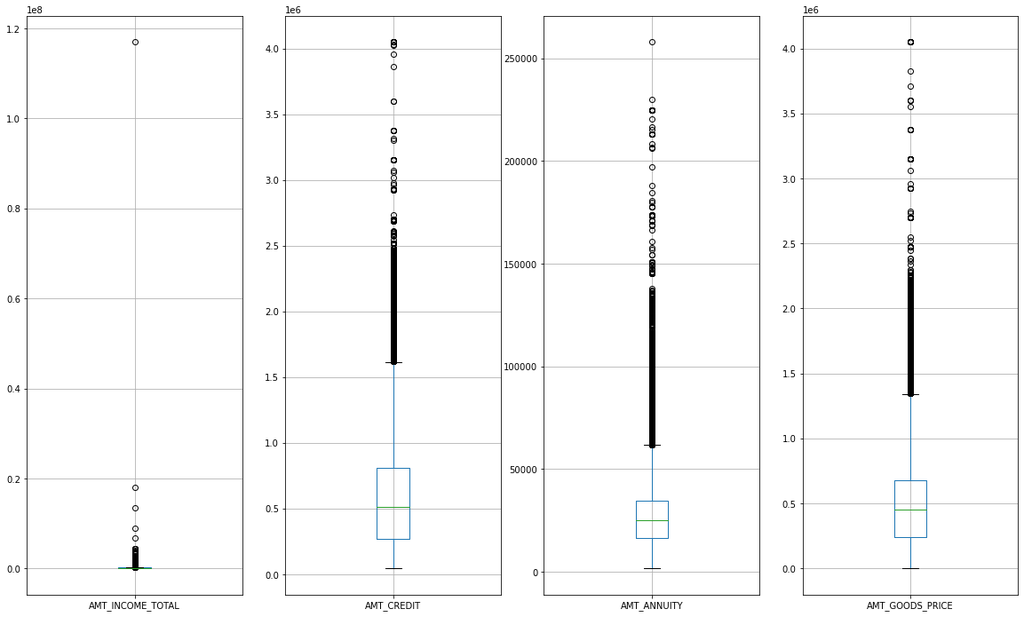

```python
#Plotting Box-plot inorder to detect outlier presence for selected columns
check_outliers = ['AMT_INCOME_TOTAL','AMT_CREDIT','AMT_ANNUITY','AMT_GOODS_PRICE']
plt.figure(figsize=(20,12))
for j, check in enumerate(check_outliers):
    plt.subplot(1,4, j+1)
    app_df.boxplot(column = check)
plt.show()
```

```python
#Dealing with outliers using 1.5 IQR method for selected column
for check in check_outliers:
    q1 = app_df[check].quantile(0.25)
    q3 = app_df[check].quantile(0.75)
    iqr = q3-q1
    range_low  = q1-1.5*iqr
    range_high = q3+1.5*iqr
    app_df = app_df.loc[(app_df[check] > range_low) & (app_df[check] < range_high)]
```

### 5. Grouping/Bucketing of Data

```python
#Bucketing the data of 'AMT_INCOME_TOTAL','AMT_CREDIT' & 'AGE_GROUPS' and storing them in a new column
#Dividing AMT_INCOME_TOTAL into groups and storing it in new INCOME column
app_df['INCOME'] = pd.qcut(app_df['AMT_INCOME_TOTAL'], q=[0, 0.2, 0.5, 0.8, 0.95, 1], labels=['VERY_LOW', 'LOW', "MEDIUM", 'HIGH', 'VERY_HIGH'])
app_df['INCOME'].unique()
```

```
['MEDIUM', 'HIGH', 'VERY_LOW', 'LOW', 'VERY_HIGH']
Categories (5, object): ['VERY_LOW' < 'LOW' < 'MEDIUM' < 'HIGH' < 'VERY_HIGH']
```

```python
# Dividing AMT_CREDIT column into groups and storing it in new CREDIT_RANGE column
app_df['CREDIT_RANGE'] = pd.qcut(app_df['AMT_CREDIT'], q=[0, 0.2, 0.5, 0.8, 0.95, 1], labels=['VERY_LOW', 'LOW', "MEDIUM", 'HIGH', 'VERY_HIGH'])
app_df['CREDIT_RANGE'].unique()
```

```
['LOW', 'VERY_HIGH', 'VERY_LOW', 'MEDIUM', 'HIGH']
Categories (5, object): ['VERY_LOW' < 'LOW' < 'MEDIUM' < 'HIGH' < 'VERY_HIGH']
```

```python
# Dividing DAYS_BIRTH column into groups and storing it in new AGE_GROUPS column
def DAYS_BIRTH_CAT(DAYS_BIRTH):
    if DAYS_BIRTH <= 30:
        return 'Young'
    elif DAYS_BIRTH > 30 and DAYS_BIRTH <= 50:
        return 'Mid Age'
    else:
        return 'Old'

app_df['AGE_GROUPS'] = app_df['DAYS_BIRTH'].apply(DAYS_BIRTH_CAT)
```

### 6. Calculating Imbalance Ratio

```python
# Calculating ratio of the applicants with no payment difficulties (Target = 0) and with payment difficulties (Target = 1)
app_df['TARGET'].value_counts(normalize = True)*100
```

```
0    91.627244
1     8.372756
Name: TARGET, dtype: float64
```

```python
#Finding Target 0 to Target 1 ratio
round(app_df[app_df.TARGET==0].shape[0]/app_df[app_df.TARGET==1].shape[0],2)
```

```
10.94
```

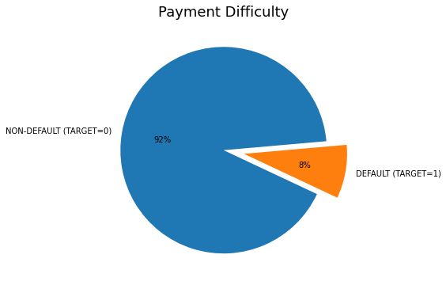

```python
#Plotting Pie-Chart for Imbalance in Data
plt.figure(figsize=(6,6))
plt.pie(app_df['TARGET'].value_counts(normalize=True)*100,labels=['NON-DEFAULT (TARGET=0)','DEFAULT (TARGET=1)'],explode=(0,0.2), startangle=5,autopct='%1.f%%')
plt.title('Payment Difficulty',fontsize= 18,fontweight= 9,color='Black')
plt.show()
```

**Inferences** `DATA IMBALANCE DETECTED`

- An imbalance is observed in the proportion of default (TARGET = 1) and non-default (TARGET = 0) in the dataset.
- The imbalane ratio is **10.94**
- 1 in every 11 applicant has payment difficulty.

```python
# Dividing the original dataset into two different datasets depending on the basis of target values
target_nondefault=app_df.loc[app_df["TARGET"]==0] #Loan-Non Payment Difficulties
target_default=app_df.loc[app_df["TARGET"]==1]#Loan Payment Difficulties
```

## PART B: Exploratory Data Analysis

```python
#First dataframe target_default with TARGET = 1 (payment defaulted Customers)
target_default = app_df.loc[app_df['TARGET'] == 1]
print('Size of the default dataset',target_default.shape)
display(target_nondefault.head())

print("\n\n\n")


#Second dataframe target_nondefault with TARGET = 0 (payment non Defaulted Customers)
target_nondefault = app_df.loc[app_df['TARGET'] == 0]
print('Size of the non-default dataset',target_nondefault.shape)
display(target_nondefault.head())
```

```
Size of the default dataset (23150, 42)
```

|  | SK_ID_CURR | TARGET | NAME_CONTRACT_TYPE | CODE_GENDER | FLAG_OWN_CAR | FLAG_OWN_REALTY | CNT_CHILDREN | AMT_INCOME_TOTAL | AMT_CREDIT | AMT_ANNUITY | AMT_GOODS_PRICE | NAME_INCOME_TYPE | NAME_EDUCATION_TYPE | NAME_FAMILY_STATUS | NAME_HOUSING_TYPE | REGION_POPULATION_RELATIVE | DAYS_BIRTH | DAYS_EMPLOYED | DAYS_REGISTRATION | DAYS_ID_PUBLISH | OCCUPATION_TYPE | REGION_RATING_CLIENT | REGION_RATING_CLIENT_W_CITY | WEEKDAY_APPR_PROCESS_START | HOUR_APPR_PROCESS_START | REG_REGION_NOT_LIVE_REGION | REG_REGION_NOT_WORK_REGION | LIVE_REGION_NOT_WORK_REGION | REG_CITY_NOT_LIVE_CITY | … |
| --- | --- | --- | --- | --- | --- | --- | --- | --- | --- | --- | --- | --- | --- | --- | --- | --- | --- | --- | --- | --- | --- | --- | --- | --- | --- | --- | --- | --- | --- | --- |
| 1 | 100003 | 0 | Cash loans | F | N | N | 0 | 270000.0 | 1293502.5 | 35698.5 | 1129500 | State servant | Higher education | Married | House / apartment | 0.003541 | 45 | 1188 | 1186.0 | 291 | Core staff | 1 | 1 | MONDAY | 11 | 0 | 0 | 0 | 0 | … |
| 2 | 100004 | 0 | Revolving loans | M | Y | Y | 0 | 67500.0 | 135000.0 | 6750.0 | 135000 | Working | Secondary / secondary special | Single / not married | House / apartment | 0.010032 | 52 | 225 | 4260.0 | 2531 | Laborers | 2 | 2 | MONDAY | 9 | 0 | 0 | 0 | 0 | … |
| 3 | 100006 | 0 | Cash loans | F | N | Y | 0 | 135000.0 | 312682.5 | 29686.5 | 297000 | Working | Secondary / secondary special | Civil marriage | House / apartment | 0.008019 | 52 | 3039 | 9833.0 | 2437 | Laborers | 2 | 2 | WEDNESDAY | 17 | 0 | 0 | 0 | 0 | … |
| 4 | 100007 | 0 | Cash loans | M | N | Y | 0 | 121500.0 | 513000.0 | 21865.5 | 513000 | Working | Secondary / secondary special | Single / not married | House / apartment | 0.028663 | 54 | 3038 | 4311.0 | 3458 | Core staff | 2 | 2 | THURSDAY | 11 | 0 | 0 | 0 | 0 | … |
| 5 | 100008 | 0 | Cash loans | M | N | Y | 0 | 99000.0 | 490495.5 | 27517.5 | 454500 | State servant | Secondary / secondary special | Married | House / apartment | 0.035792 | 46 | 1588 | 4970.0 | 477 | Laborers | 2 | 2 | WEDNESDAY | 16 | 0 | 0 | 0 | 0 | … |

```
Size of the non-default dataset (253342, 42)
```

|  | SK_ID_CURR | TARGET | NAME_CONTRACT_TYPE | CODE_GENDER | FLAG_OWN_CAR | FLAG_OWN_REALTY | CNT_CHILDREN | AMT_INCOME_TOTAL | AMT_CREDIT | AMT_ANNUITY | AMT_GOODS_PRICE | NAME_INCOME_TYPE | NAME_EDUCATION_TYPE | NAME_FAMILY_STATUS | NAME_HOUSING_TYPE | REGION_POPULATION_RELATIVE | DAYS_BIRTH | DAYS_EMPLOYED | DAYS_REGISTRATION | DAYS_ID_PUBLISH | OCCUPATION_TYPE | REGION_RATING_CLIENT | REGION_RATING_CLIENT_W_CITY | WEEKDAY_APPR_PROCESS_START | HOUR_APPR_PROCESS_START | REG_REGION_NOT_LIVE_REGION | REG_REGION_NOT_WORK_REGION | LIVE_REGION_NOT_WORK_REGION | REG_CITY_NOT_LIVE_CITY | … |
| --- | --- | --- | --- | --- | --- | --- | --- | --- | --- | --- | --- | --- | --- | --- | --- | --- | --- | --- | --- | --- | --- | --- | --- | --- | --- | --- | --- | --- | --- | --- |
| 1 | 100003 | 0 | Cash loans | F | N | N | 0 | 270000.0 | 1293502.5 | 35698.5 | 1129500 | State servant | Higher education | Married | House / apartment | 0.003541 | 45 | 1188 | 1186.0 | 291 | Core staff | 1 | 1 | MONDAY | 11 | 0 | 0 | 0 | 0 | … |
| 2 | 100004 | 0 | Revolving loans | M | Y | Y | 0 | 67500.0 | 135000.0 | 6750.0 | 135000 | Working | Secondary / secondary special | Single / not married | House / apartment | 0.010032 | 52 | 225 | 4260.0 | 2531 | Laborers | 2 | 2 | MONDAY | 9 | 0 | 0 | 0 | 0 | … |
| 3 | 100006 | 0 | Cash loans | F | N | Y | 0 | 135000.0 | 312682.5 | 29686.5 | 297000 | Working | Secondary / secondary special | Civil marriage | House / apartment | 0.008019 | 52 | 3039 | 9833.0 | 2437 | Laborers | 2 | 2 | WEDNESDAY | 17 | 0 | 0 | 0 | 0 | … |
| 4 | 100007 | 0 | Cash loans | M | N | Y | 0 | 121500.0 | 513000.0 | 21865.5 | 513000 | Working | Secondary / secondary special | Single / not married | House / apartment | 0.028663 | 54 | 3038 | 4311.0 | 3458 | Core staff | 2 | 2 | THURSDAY | 11 | 0 | 0 | 0 | 0 | … |
| 5 | 100008 | 0 | Cash loans | M | N | Y | 0 | 99000.0 | 490495.5 | 27517.5 | 454500 | State servant | Secondary / secondary special | Married | House / apartment | 0.035792 | 46 | 1588 | 4970.0 | 477 | Laborers | 2 | 2 | WEDNESDAY | 16 | 0 | 0 | 0 | 0 | … |

### 1. Univariate Analysis

```python
#Displaying the names of all the columns
target_default.columns
```

```
Index(['SK_ID_CURR', 'TARGET', 'NAME_CONTRACT_TYPE', 'CODE_GENDER',
       'FLAG_OWN_CAR', 'FLAG_OWN_REALTY', 'CNT_CHILDREN', 'AMT_INCOME_TOTAL',
       'AMT_CREDIT', 'AMT_ANNUITY', 'AMT_GOODS_PRICE', 'NAME_INCOME_TYPE',
       'NAME_EDUCATION_TYPE', 'NAME_FAMILY_STATUS', 'NAME_HOUSING_TYPE',
       'REGION_POPULATION_RELATIVE', 'DAYS_BIRTH', 'DAYS_EMPLOYED',
       'DAYS_REGISTRATION', 'DAYS_ID_PUBLISH', 'OCCUPATION_TYPE',
       'REGION_RATING_CLIENT', 'REGION_RATING_CLIENT_W_CITY',
       'WEEKDAY_APPR_PROCESS_START', 'HOUR_APPR_PROCESS_START',
       'REG_REGION_NOT_LIVE_REGION', 'REG_REGION_NOT_WORK_REGION',
       'LIVE_REGION_NOT_WORK_REGION', 'REG_CITY_NOT_LIVE_CITY',
       'REG_CITY_NOT_WORK_CITY', 'LIVE_CITY_NOT_WORK_CITY',
       'ORGANIZATION_TYPE', 'EXT_SOURCE_2', 'AMT_REQ_CREDIT_BUREAU_HOUR',
       'AMT_REQ_CREDIT_BUREAU_DAY', 'AMT_REQ_CREDIT_BUREAU_WEEK',
       'AMT_REQ_CREDIT_BUREAU_MON', 'AMT_REQ_CREDIT_BUREAU_QRT',
       'AMT_REQ_CREDIT_BUREAU_YEAR', 'INCOME', 'CREDIT_RANGE', 'AGE_GROUPS'],
      dtype='object')
```

```python
#Filtering categorical columns
list(set(target_default.columns)-set(target_default.describe().columns))
```

```
['NAME_INCOME_TYPE',
 'FLAG_OWN_CAR',
 'NAME_CONTRACT_TYPE',
 'OCCUPATION_TYPE',
 'CREDIT_RANGE',
 'INCOME',
 'NAME_EDUCATION_TYPE',
 'NAME_HOUSING_TYPE',
 'CODE_GENDER',
 'WEEKDAY_APPR_PROCESS_START',
 'FLAG_OWN_REALTY',
 'NAME_FAMILY_STATUS',
 'AGE_GROUPS',
 'ORGANIZATION_TYPE']
```

```python
#After analyzing the columns, reached to below conculsion:
categorical = ['TARGET','NAME_CONTRACT_TYPE', 'CODE_GENDER', 'FLAG_OWN_CAR', 'FLAG_OWN_REALTY', 'NAME_INCOME_TYPE',
       'NAME_EDUCATION_TYPE', 'NAME_FAMILY_STATUS', 'NAME_HOUSING_TYPE', 'INCOME_CATEGORY',
               'AGE_CATEGORY', 'CREDIT_CATEGORY']

continious = ['AMT_INCOME_TOTAL','AMT_CREDIT', 'AMT_ANNUITY', 'AMT_GOODS_PRICE', 'DAYS_BIRTH', 'DAYS_EMPLOYED',
              'EXT_SOURCE_2', 'EXT_SOURCE_3']
```

#### A. Categorical Univariate Analysis

```python
#Creating the function Categorical_plot inorder to visualize the different columns w.r.t both Dataframes(target_default & target_nondefault)
def Categorical_plot(val,r): #Val is column name & r is the rotation angle for x ticks

    sns.set_style("whitegrid")
    f,(ax1,ax2) =plt.subplots(1,2,figsize=(20, 7))

    default_plot=sns.countplot(x = val, data = target_default,ax=ax1)
    default_plot.set_title(f"\nDefaulters\n", fontsize=24,fontweight= 7,color='Black')
    default_plot.set_xlabel(f"\n{val} \n\n", fontsize=16,fontweight= 10,color='Blue')
    default_plot.set_ylabel("\nTotal Counts\n", fontsize=16,fontweight= 10,color='Blue')
    default_plot.set_xticklabels(default_plot.get_xticklabels(), rotation = r, fontsize = 18, color="Black")


    default_plot=sns.countplot(x = val, data = target_nondefault,ax=ax2)
    default_plot.set_title(f"\nNon-Defaulters\n", fontsize=24,fontweight= 7,color='Black')
    default_plot.set_xlabel(f"\n{val} \n\n", fontsize=16,fontweight= 10,color='Blue')
    default_plot.set_ylabel("\nTotal Counts\n", fontsize=16,fontweight= 10,color='Blue')
    default_plot.set_xticklabels(default_plot.get_xticklabels(), rotation = r, fontsize = 18, color="Black")

    plt.show()
```

```python
#Creating the function proportion inorder to visualize the proportions of defaulters.
def proportion(val,r):
    plt.figure(figsize=(15,5))
    prop = pd.DataFrame(app_df.groupby([val])['TARGET'].value_counts()/app_df.groupby([val])['TARGET'].count())*100
    prop.columns = ['Per_Target']
    target = pd.pivot_table(prop, values ='Per_Target', index = val,columns =['TARGET'], aggfunc = np.sum)
    target = target.reset_index()
    target.drop(0, axis = 1, inplace = True)
    target.columns = [val,'Non-default']
    ax2 = sns.barplot(x= val, y= 'Non-default',palette="muted", data= target)
    ax2.set_xlabel(f'{val}', fontsize=16,fontweight= 10,color='Blue')
    ax2.set_ylabel('Proportion of default',fontsize=16,fontweight= 10,color='Blue')
    ax2.set_title(f'Proportion of default w.r.t {val}', fontsize=24,fontweight= 7,color='Black')
    ax2.set_xticklabels(ax2.get_xticklabels(), rotation = r, fontsize = 18, color="Black")
    plt.show()
```

- **Variable 1: Contract Type**

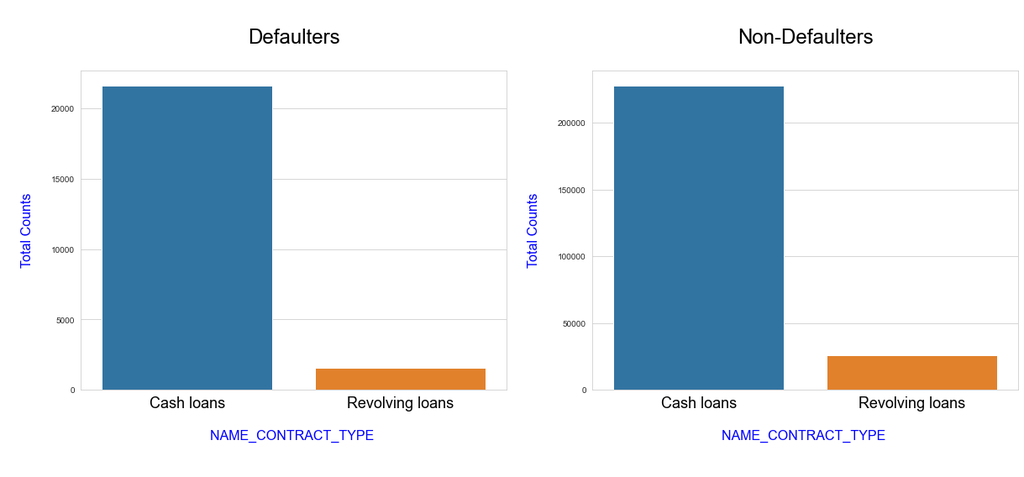

```python
#Analyzing NAME_CONTRACT_TYPE column using Categorical_plot function
Categorical_plot('NAME_CONTRACT_TYPE',0)
```

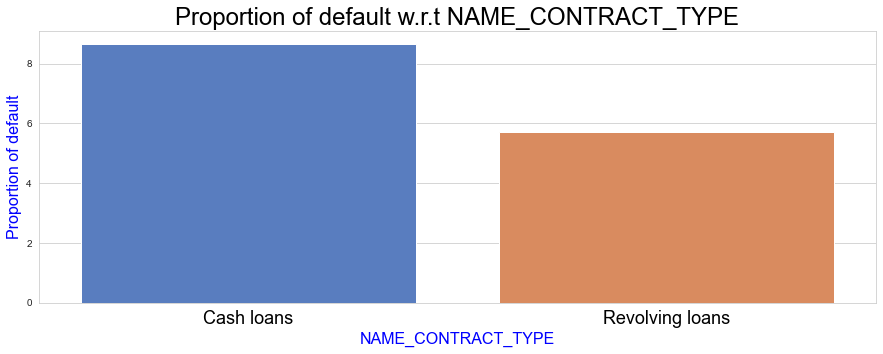

```python
#Finding proportion of Default Clients on the basis of NAME_CONTRACT_TYPE
proportion('NAME_CONTRACT_TYPE',0)
```

**`Inferences:`**

- Both default and non-default type, Count for Cash Loans is higher than Revolving loans.
- Cash Loan type is having higher proportion of default.
- **Variable 2: Gender**

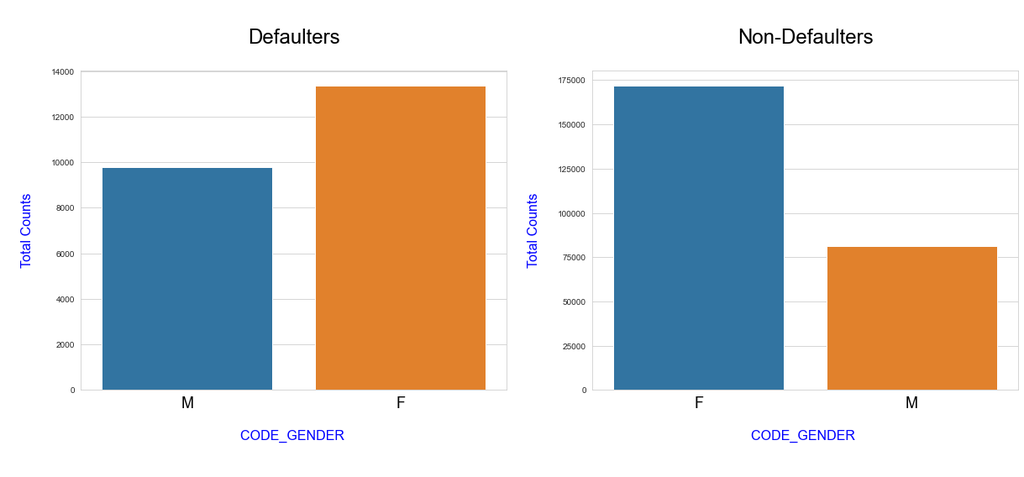

```python
#Analyzing CODE_GENDER column using Categorical_plot function
Categorical_plot('CODE_GENDER',0)
```

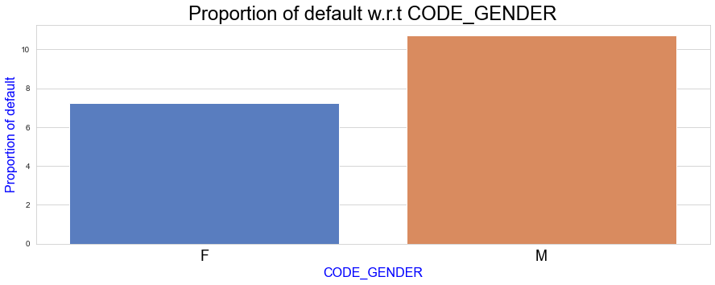

```python
#Finding proportion of Default Clients on the basis of CODE_GENDER
proportion('CODE_GENDER',0)
```

**`Inferences:`**

- Both default and non-default type, Count for Female is higher than Male.
- Male are having higher proportion of default.
- **Variable 3: Car Status**

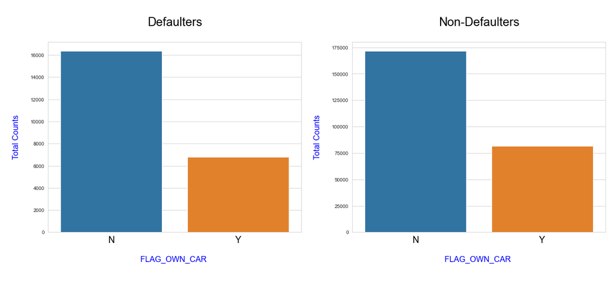

```python
#Analyzing FLAG_OWN_CAR column using Categorical_plot function
Categorical_plot('FLAG_OWN_CAR',0)
```

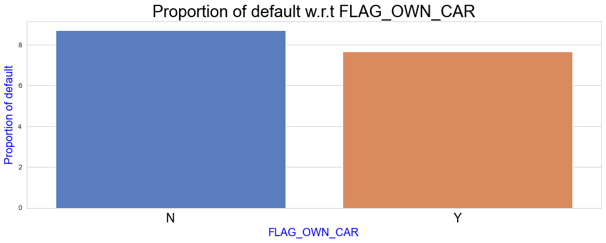

```python
#Finding proportion of Default Clients on the basis of FLAG_OWN_CAR
proportion('FLAG_OWN_CAR',0)
```

**`Inferences:`**

- Both default and non-default type, Count for Non car owners is higher.
- Non-Car owners are having slighly higher proportion of default.
- **Variable 4: Real-Estate Status**

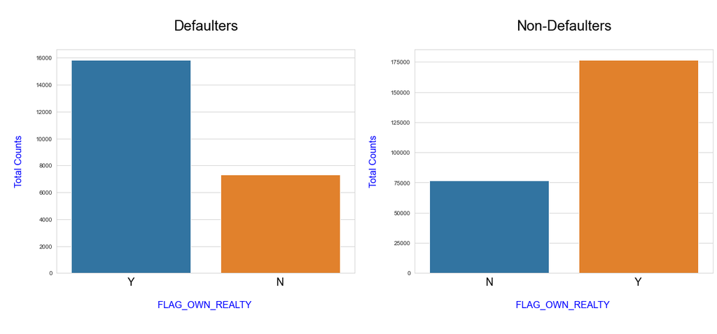

```python
#Analyzing FLAG_OWN_REALTY column using Categorical_plot function
Categorical_plot('FLAG_OWN_REALTY',0)
```

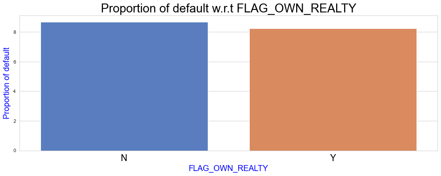

```python
#Finding proportion of Default Clients on the basis of FLAG_OWN_REALTY
proportion('FLAG_OWN_REALTY',0)
```

**`Inferences:`**

- Both default and non-default type, Count for Real Estate owner is higher.
- Clients who are not Real Estate owners are having slighly higher proportion of default.
- **Variable 5: Type of Income**

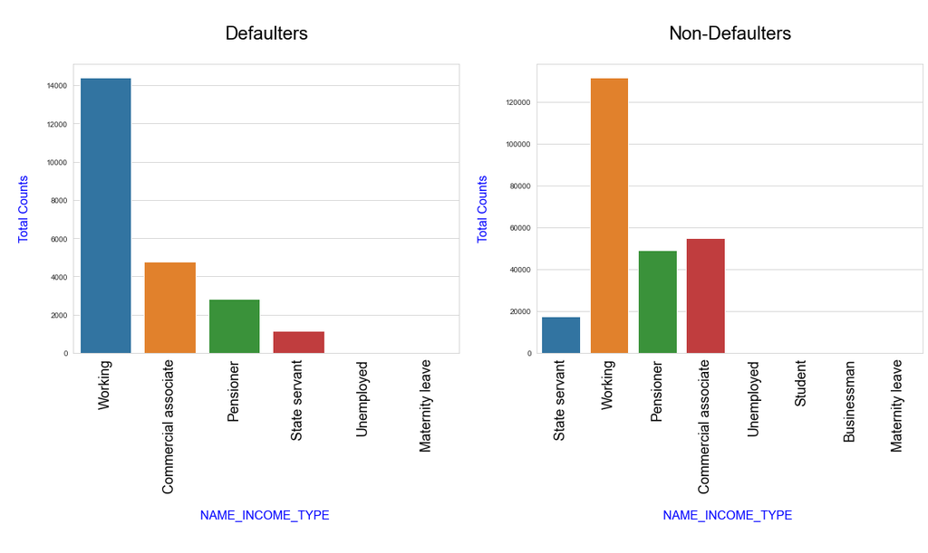

```python
#Analyzing NAME_INCOME_TYPE column using Categorical_plot function
Categorical_plot('NAME_INCOME_TYPE',90)
```

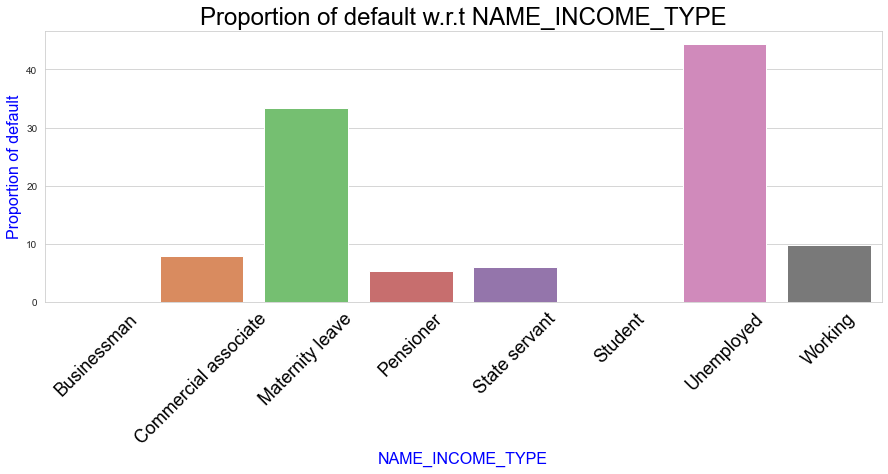

```python
#Finding proportion of Default Clients on the basis of NAME_INCOME_TYPE
proportion('NAME_INCOME_TYPE',45)
```

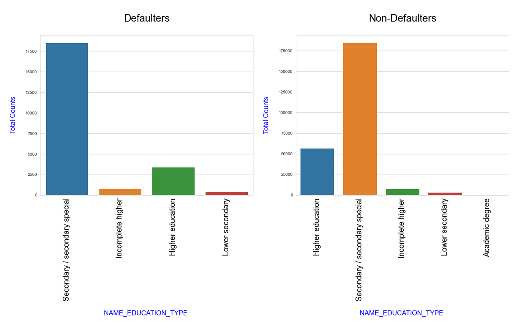

```python
#Analyzing NAME_EDUCATION_TYPE column using Categorical_plot function
Categorical_plot('NAME_EDUCATION_TYPE',90)
```

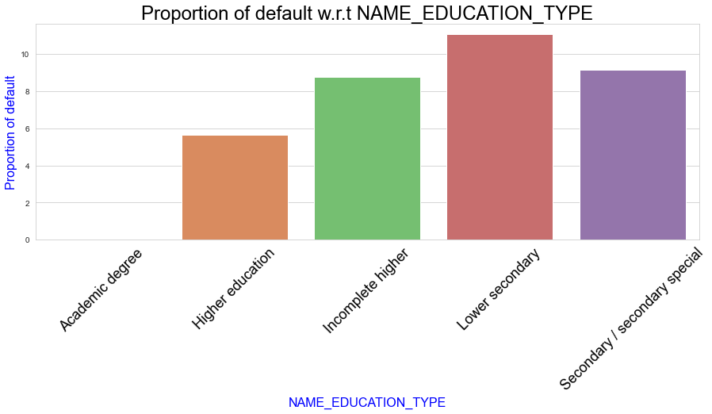

```python
#Finding proportion of Default Clients on the basis of NAME_EDUCATION_TYPE
proportion('NAME_EDUCATION_TYPE',45)
```

**`Inferences:`**

- Both default and non-default type, Count for clients with secondary education is higher.
- Clients with lower secondary education posses higher proportion of default.
- **Variable 7: Family Status**

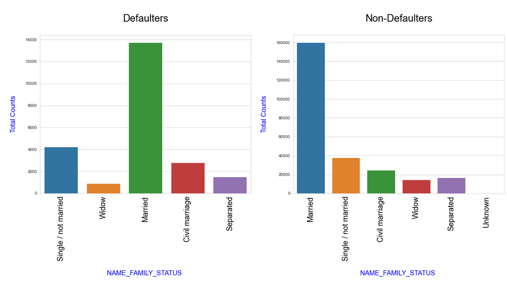

```python
#Analyzing NAME_FAMILY_STATUS column using Categorical_plot function
Categorical_plot('NAME_FAMILY_STATUS',90)
```

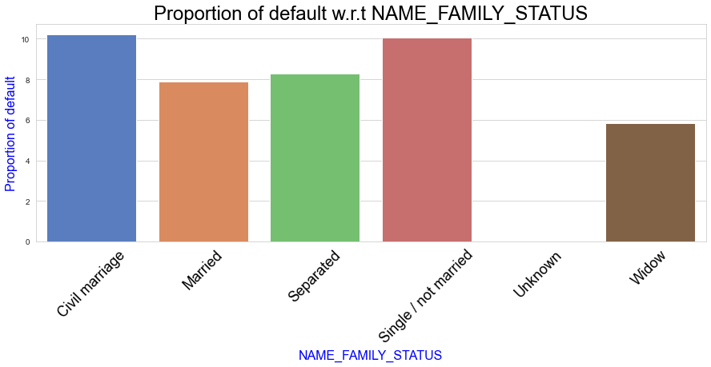

```python
#Finding proportion of Default Clients on the basis of NAME_FAMILY_STATUS
proportion('NAME_FAMILY_STATUS',45)
```

**`Inferences:`**

- Both default and non-default type, Count for married clients is higher.
- Clients with civil marriage have higher proportion of default.
- **Variable 8: Income**

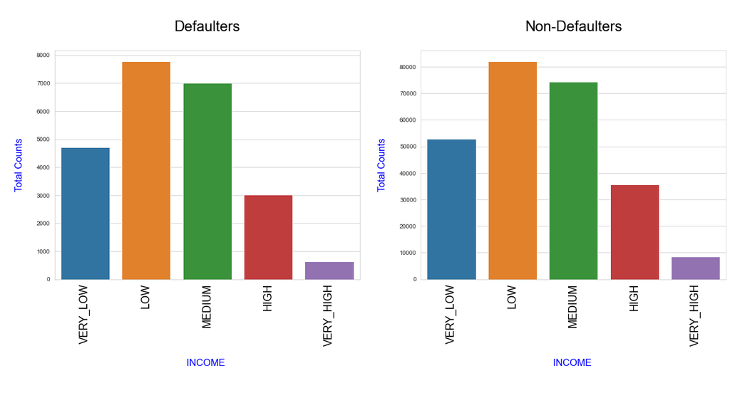

```python
#Analyzing INCOME column using Categorical_plot function
Categorical_plot('INCOME',90)
```

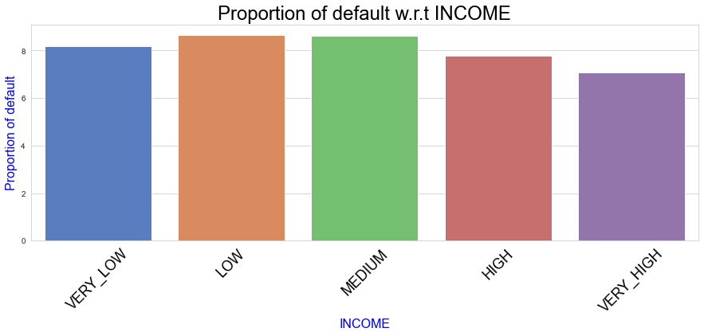

```python
#Finding proportion of Default Clients on the basis of INCOME
proportion('INCOME',45)
```

**`Inferences:`**

- Both default and non-default type, Count for clients with lower income range is higher.
- Clients with low and medium income scale are having sligtly higher proportion of default as compared to other income classes.
- **Variable 9: Credit Range**

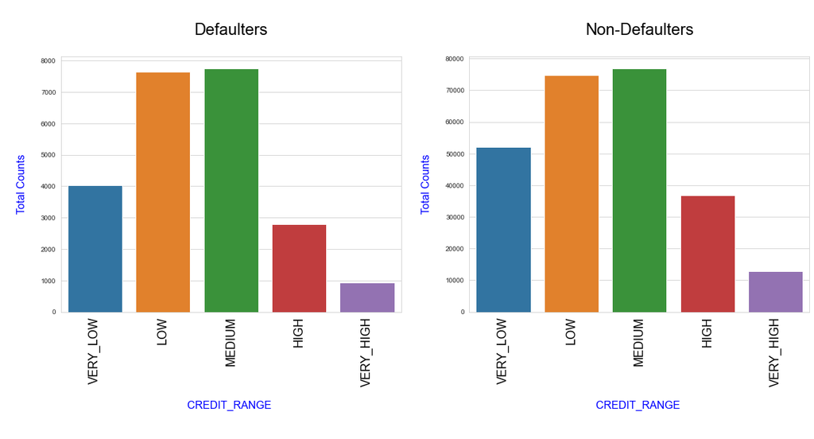

```python
#Analyzing CREDIT_RANGE column using Categorical_plot function
Categorical_plot('CREDIT_RANGE',90)
```

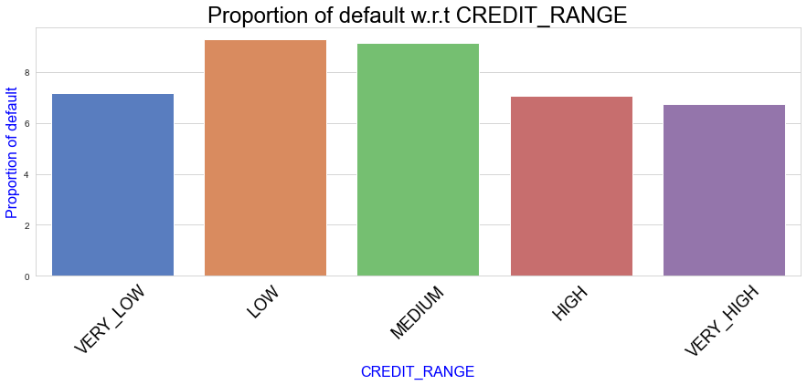

```python
#Finding proportion of Default Clients on the basis of CREDIT_RANGE
proportion('CREDIT_RANGE',45)
```

**`Inferences:`**

- Both default and non-default type, Count for clients with low and medium credit range is higher.
- Clients with low and medium credit range have higher proportion of default.
- **Variable 10: Age-Group**

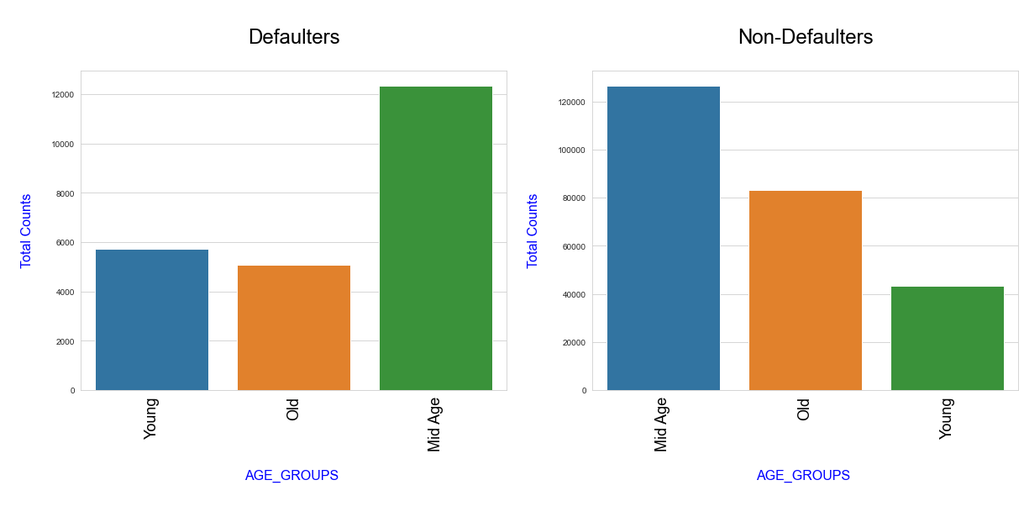

```python
#Analyzing AGE_GROUPS column using Categorical_plot function
Categorical_plot('AGE_GROUPS',90)
```

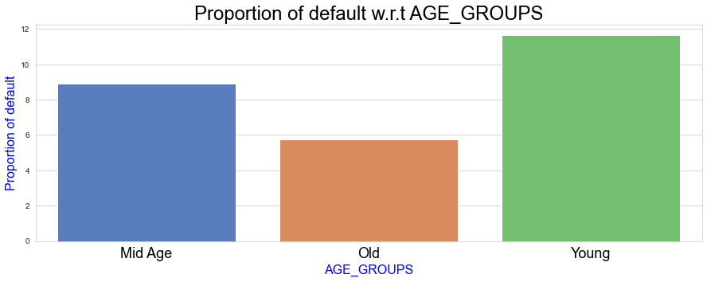

```python
#Finding proportion of Default Clients on the basis of AGE_GROUPS
proportion('AGE_GROUPS',0)
```

### B. Continous Univariate Analysis

```python
#Creating the function Continous_plot inorder to visualize the different contionous valued columns w.r.t both Dataframes(target_default & target_nondefault)
def Continous_plot(val):
    sns.set_style("whitegrid", {"grid.color": ".6", "grid.linestyle": ":"})
    plt.figure(figsize=(8,5))
    sns.distplot(target_default[val], hist =False,label = 'DEFAULT')
    sns.distplot(target_nondefault[val], hist =False,label = 'NON-DEFAULT')
    plt.legend()
    plt.title(f'{val}')
    plt.show()
```

- **Variable 1: DAYS_BIRTH**

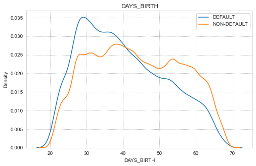

```python
#Analyzing DAYS_BIRTH column using Continous_plot function
Continous_plot('DAYS_BIRTH')
```

**`Inferences:`**

- Age group 30 to 40 years posses higher default clients
- Non default clients are equally ditributed through the curve.
- **Variable 2: AMT_INCOME_TOTAL**

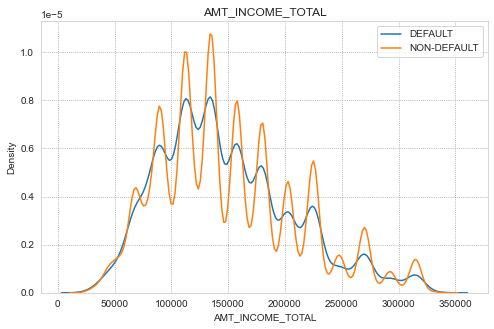

```python
#Analyzing AMT_INCOME_TOTAL column using Continous_plot function
Continous_plot('AMT_INCOME_TOTAL')
```

**`Inferences:`**

- Both deafult type and Non default type are having similar pattern with different frequency.
- As per plot, it seems like people with income 15k to 20k and 50k are more likely to default.
- **Variable 3: AMT_GOODS_PRICE**

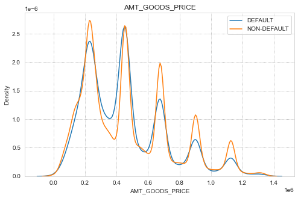

```python
#Analyzing AMT_GOODS_PRICE column using Continous_plot function
Continous_plot('AMT_GOODS_PRICE')
```

**`Inferences:`**

- Both deafult type and Non default type are having similar pattern.
- As the good price gets higher, lesser is the number of deafaults.
- **Variable 4: AMT_CREDIT**

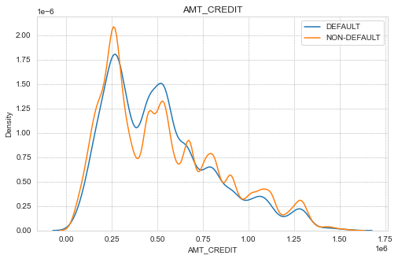

```python
#Analyzing AMT_CREDIT column using Continous_plot function
Continous_plot('AMT_CREDIT')
```

**`Inferences:`**

- Both deafult type and Non default type are having similar pattern.
- As the credit amount increases, lower gets the chances of default.
- **Variable 5: AMT_ANNUITY**

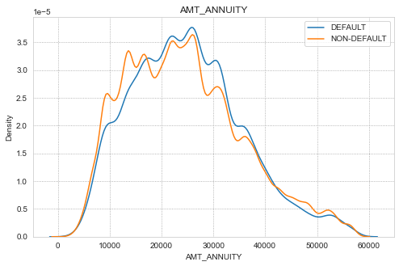

```python
#Analyzing AMT_ANNUITY column using Continous_plot function
Continous_plot('AMT_ANNUITY')
```

**`Inferences:`**